# hw03

2017-10-02

### By Susanna Klassen

```r
suppressPackageStartupMessages(library(tidyverse))  #Note to inquire/remind myself about the functionality of these options
suppressPackageStartupMessages(library(gapminder))
knitr::opts_chunk$set(fig.width=4, fig.height=3)
```

## Outline

I will be accomplishing the following tasks in this assignment 1. Look at the spread of GDP per capita within the continents. 2. How is life expectancy changing over time on different continents? 3. Find countries with interesting stories. Open-ended and, therefore, hard. Promising but unsuccessful attempts are encouraged. This will generate interesting questions to follow up on in class.

```r
library(gapminder)
library(tidyverse)
```

### 1. GDP per capita by continent

#### 1.1 Table

To look at the spread of GDP per capita by continent I will use the `groupby` function in conjunction with piping.

```r
gapminder %>%
  group_by(continent) %>%
summarize(min(gdpPercap), max(gdpPercap), mean(gdpPercap))
```

```
## # A tibble: 5 x 4
##   continent `min(gdpPercap)` `max(gdpPercap)` `mean(gdpPercap)`
##      <fctr>            <dbl>            <dbl>             <dbl>
## 1    Africa         241.1659         21951.21          2193.755
## 2  Americas        1201.6372         42951.65          7136.110
## 3      Asia         331.0000        113523.13          7902.150
## 4    Europe         973.5332         49357.19         14469.476
## 5   Oceania       10039.5956         34435.37         18621.609
```

Thinking there might be a more elegant way of getting this info (all measures of the same variable)

```r
gapminder %>%
  group_by(continent) %>%
summarize_each(funs(min, max, mean), gdpPercap) # could also add other variables here if I wanted these same stats for multiple variables
```

```
## `summarise_each()` is deprecated.
## Use `summarise_all()`, `summarise_at()` or `summarise_if()` instead.
## To map `funs` over a selection of variables, use `summarise_at()`
```

```
## # A tibble: 5 x 4
##   continent gdpPercap_min gdpPercap_max gdpPercap_mean
##      <fctr>         <dbl>         <dbl>          <dbl>
## 1    Africa      241.1659      21951.21       2193.755
## 2  Americas     1201.6372      42951.65       7136.110
## 3      Asia      331.0000     113523.13       7902.150
## 4    Europe      973.5332      49357.19      14469.476
## 5   Oceania    10039.5956      34435.37      18621.609
```

That also worked!

#### 1.2 Figure

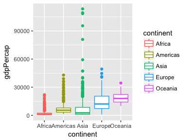

```r
gapminder %>%
  group_by(continent) %>%
  ggplot(aes(x = continent, y = gdpPercap)) + geom_boxplot(aes(colour=continent))
```

This boxplot clearly depicts how the spread of GDP per capita differs between continents, and allows us to get a much better sense of the spread of values more quickly than with the table. For example, the range of values for Africa is quite narrow, versus that of Asia or Europe, both of which exhibit different trends in central tendency.

### 2. Changes in life expectancy over time by continent

#### 2.1 Table

I’ll create a table that uses the `mutate` function to display changes in life expectancy over time by continent. I will also select only the variables I want to display (dropping pop and gdpPercap).

```r
gapminder %>%
  group_by(continent) %>%
  select(country, continent, year, lifeExp) %>%
  mutate(lifeExp_change = lifeExp - lifeExp[1])
```

```
## # A tibble: 1,704 x 5
## # Groups:   continent [5]
##        country continent  year lifeExp lifeExp_change
##         <fctr>    <fctr> <int>   <dbl>          <dbl>
##  1 Afghanistan      Asia  1952  28.801          0.000
##  2 Afghanistan      Asia  1957  30.332          1.531
##  3 Afghanistan      Asia  1962  31.997          3.196
##  4 Afghanistan      Asia  1967  34.020          5.219
##  5 Afghanistan      Asia  1972  36.088          7.287
##  6 Afghanistan      Asia  1977  38.438          9.637
##  7 Afghanistan      Asia  1982  39.854         11.053
##  8 Afghanistan      Asia  1987  40.822         12.021
##  9 Afghanistan      Asia  1992  41.674         12.873
## 10 Afghanistan      Asia  1997  41.763         12.962
## # ... with 1,694 more rows
```

#### 2.2 Figure

As I’m wanting to plot two continuous variables for this task, I’ll want to use a scatter plot. I’ll fit a line to the data to better display the change in life expectancy by continent over time.

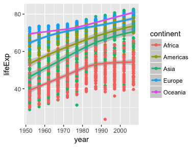

```r
gapminder %>%
  group_by(continent) %>%
  select(country, continent, year, lifeExp) %>%
  ggplot(aes(year, lifeExp,
            color = continent)) +
  geom_point() +
  geom_smooth()
```

### 3. Countries with interesting stories

#### 3.1 Exploring the Americas

My first thought is to explore GDP per capita in Venezuela, which has had a somewhat volatile political and economic history (particularly in the last few yeasrs). But before I dive into a specific country, I might as well look at trends in that continent more broadly to try to pick out some potentially interesting stories (which means I’ll need to look more broadly at the Americas).

#### 3.1.1 Life expectancy in the Americas

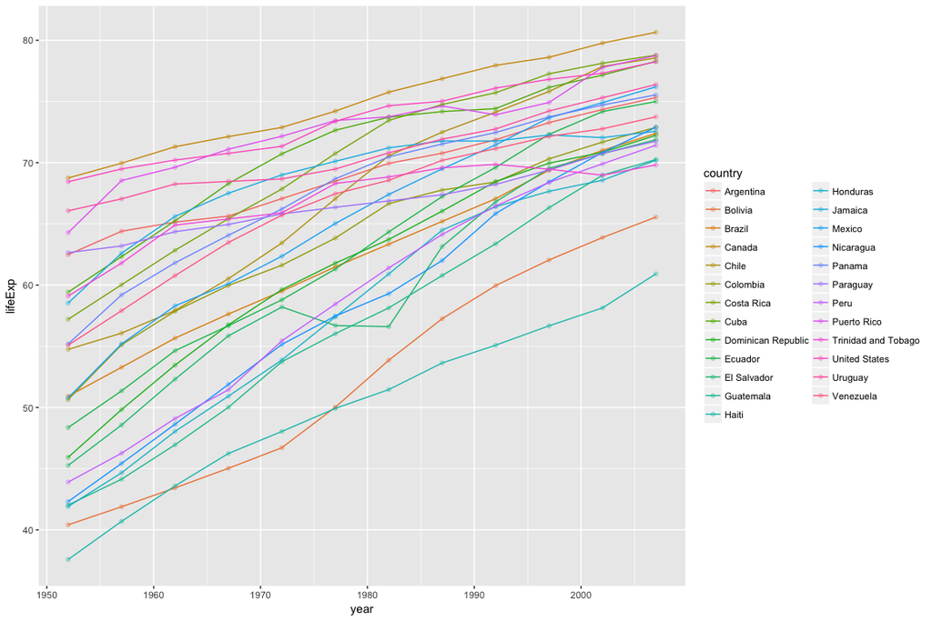

```r
gapminder %>% # altered figure width so we could see the lines better
  filter(continent == "Americas") %>%
  ggplot(aes(year, lifeExp, group=country, colour=country)) +
  geom_point(alpha=0.3) +
  geom_line()
```

Some interesting stories in there. 1. A drastic increase over this time period for some! 2. Canada consistently showing the highest value 3. The United States drops below some other countries later in this time period

#### 3.1.2 GDP per capita in the Americas

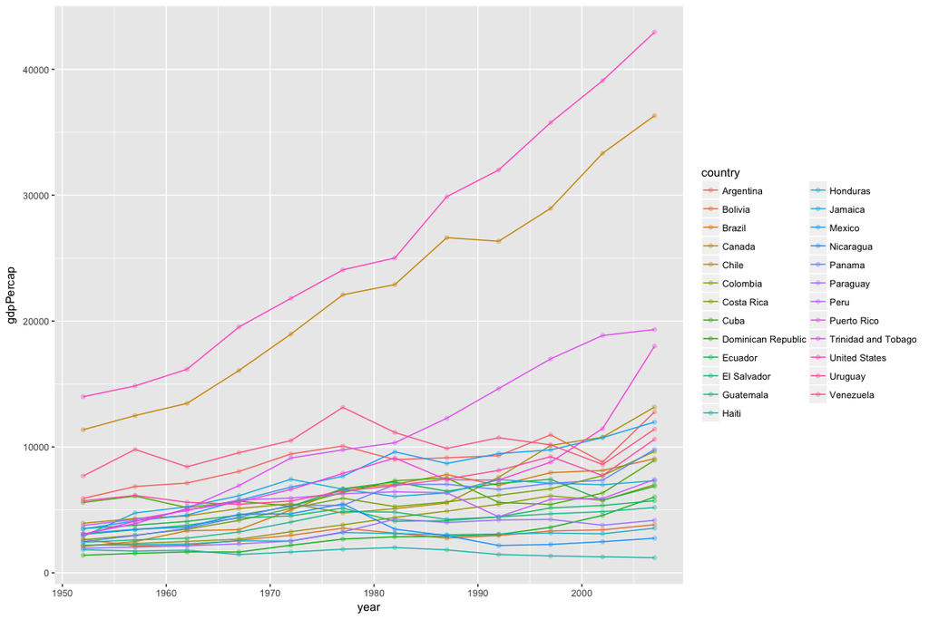

```r
gapminder %>% # altered figure width so we could see the lines better
  filter(continent == "Americas") %>%
  ggplot(aes(year, gdpPercap, group=country, colour=country)) +
  geom_point(alpha=0.3) +
  geom_line()
```

Let’s drop off Canada and the US to get a closer look at Central & South America (+ Mexico)

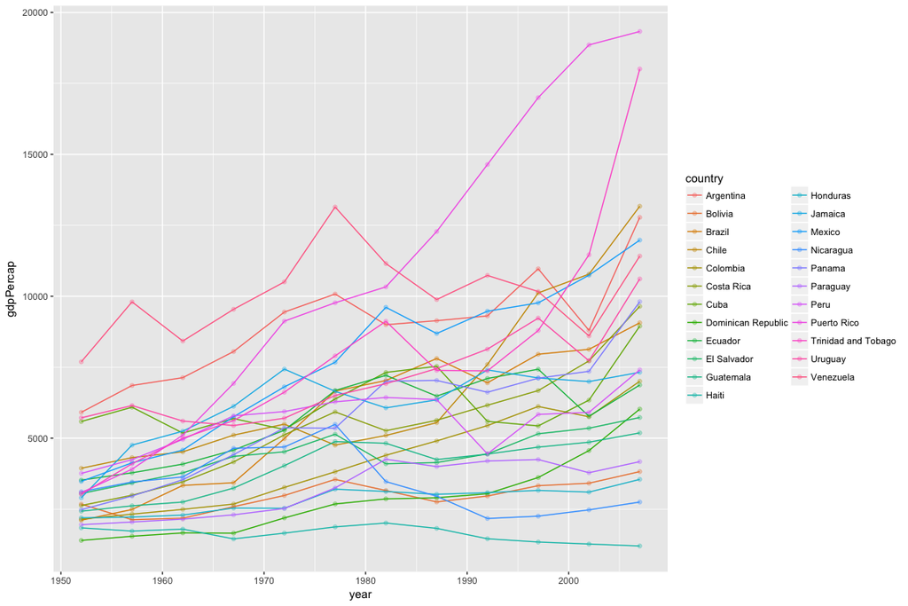

```r
gapminder %>% # altered figure width so we could see the lines better
  filter(continent == "Americas", country != "Canada", country != "United States") %>%
  ggplot(aes(year, gdpPercap, group=country, colour=country)) +
  geom_point(alpha=0.3) +
  geom_line()
```

#### 3.2 Comparing changes in GDP per capita in 5 countries

It was a bit difficult to ‘zoom’ in on a few of the more interesting patterns in the figure above, but using some trial and error (I look forward to learning a more efficient way of doing this!), I found that Venezuela, Haiti, Puerto Rico, Trinidad and Tobago, and Nicaragua all exhibited interesting trends in GDP per capita over time.

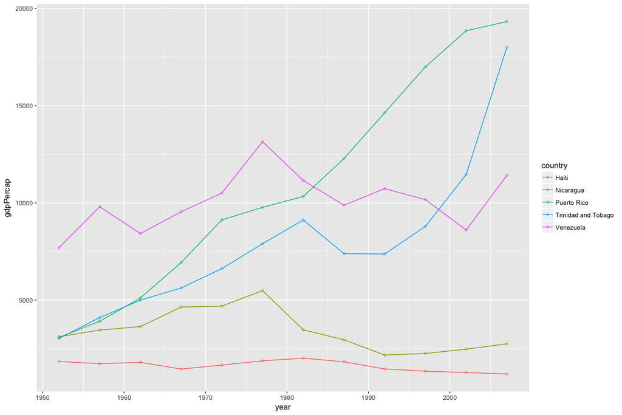

```r
gapminder %>% # altered figure width so we could see the lines better
  filter(country %in% c("Venezuela", "Haiti", "Puerto Rico", "Trinidad and Tobago", "Nicaragua")) %>%
  ggplot(aes(year, gdpPercap, group=country, colour=country)) +
  geom_point(alpha=0.3) +
  geom_line()
```

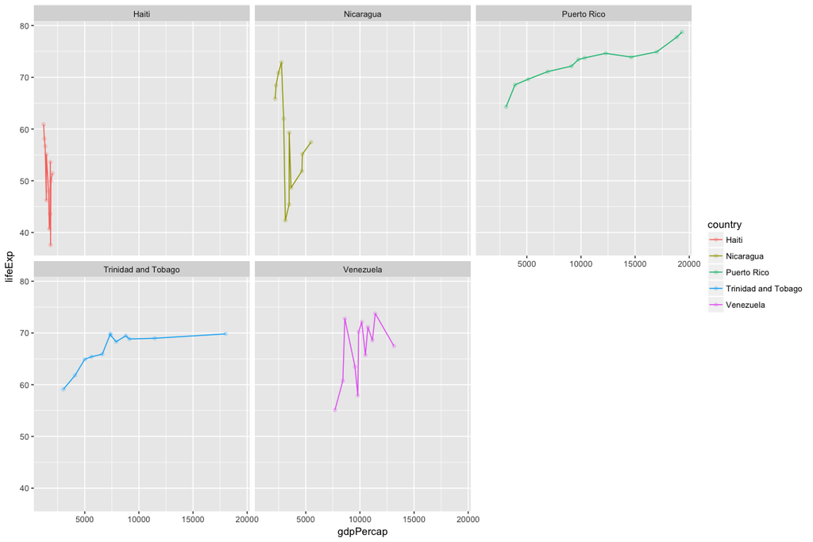

```r
gapminder %>%
  filter(country %in% c("Venezuela", "Haiti", "Puerto Rico", "Trinidad and Tobago", "Nicaragua")) %>%
  ggplot(aes(gdpPercap, lifeExp, group=country, colour=country)) +
  facet_wrap(~ country) +
  geom_point(alpha=0.2) +
  geom_line()
```

This was an imperfect attempt to display trends in GDP per capita and life expectancy (2 continuous variables) in these 5 countries using faceting. It shows something, but maybe isn’t a fully successful attempt. Part of the issue here is the common x scale. Let’s try reversing the x and y variables…

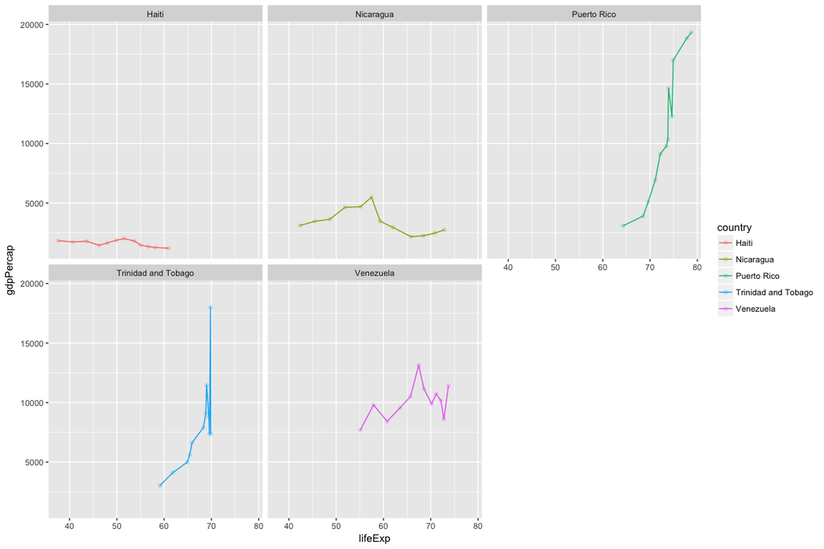

```r
gapminder %>%
  filter(country %in% c("Venezuela", "Haiti", "Puerto Rico", "Trinidad and Tobago", "Nicaragua")) %>%
  ggplot(aes(lifeExp, gdpPercap, group=country, colour=country)) +
  facet_wrap(~ country) +
  geom_point(alpha=0.2) +
  geom_line()
```

Still kind of a convoulted way to look at these variables…

All in one plot:

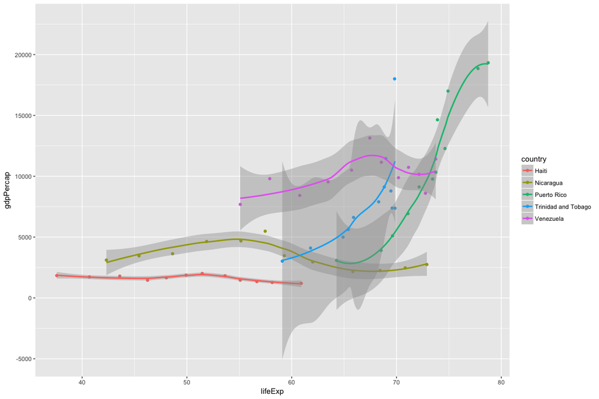

```r
gapminder %>%
  filter(country %in% c("Venezuela", "Haiti", "Puerto Rico", "Trinidad and Tobago", "Nicaragua")) %>%
  ggplot(aes(lifeExp, gdpPercap, colour=country)) +
    geom_point() +
    geom_smooth()
```

#### 3.3 Contrasting Nicaragua and Puerto Rico

Let’s look more closely at the change in GDP per capita in Puerto Rico…

```r
gapminder %>%
  filter(country == "Puerto Rico") %>%
  select(country, continent, year, pop, gdpPercap)
```

```
## # A tibble: 12 x 5
##        country continent  year     pop gdpPercap
##         <fctr>    <fctr> <int>   <int>     <dbl>
##  1 Puerto Rico  Americas  1952 2227000  3081.960
##  2 Puerto Rico  Americas  1957 2260000  3907.156
##  3 Puerto Rico  Americas  1962 2448046  5108.345
##  4 Puerto Rico  Americas  1967 2648961  6929.278
##  5 Puerto Rico  Americas  1972 2847132  9123.042
##  6 Puerto Rico  Americas  1977 3080828  9770.525
##  7 Puerto Rico  Americas  1982 3279001 10330.989
##  8 Puerto Rico  Americas  1987 3444468 12281.342
##  9 Puerto Rico  Americas  1992 3585176 14641.587
## 10 Puerto Rico  Americas  1997 3759430 16999.433
## 11 Puerto Rico  Americas  2002 3859606 18855.606
## 12 Puerto Rico  Americas  2007 3942491 19328.709
```

And comparing changes in GDP per capita over time for both countries…

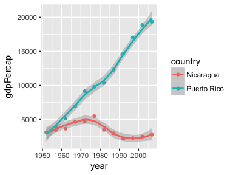

```r
gapminder %>%
  filter(country %in% c("Puerto Rico","Nicaragua")) %>%
ggplot(aes(year, gdpPercap, color = country)) +
  geom_point() +
  geom_smooth()
```

Let’s see how they compare when we factor in changes in population…

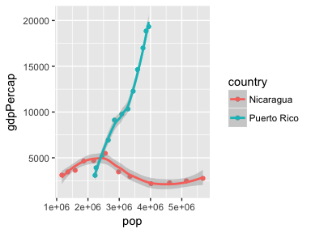

```r
gapminder %>%
  filter(country %in% c("Puerto Rico","Nicaragua")) %>%
ggplot(aes(pop, gdpPercap, color = country)) +
  geom_point() +
  geom_smooth()
```

Wow! That is super interesting… it looks like they have experienced very different trends in population growth… let’s visualize that to compare them.

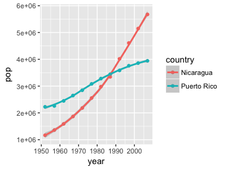

```r
gapminder %>%
  filter(country %in% c("Puerto Rico","Nicaragua")) %>%
ggplot(aes(year, pop, color = country)) +
  geom_point() +
  geom_smooth()
```

Puerto Rico has seen more gradual population growth, starting with a higher population, but Nicaragua’s population surpassed it around 1987. This shows that growth in GDP in Puerto Rico must have outpaced population growth (as the GDP per capita value becomes quite high later on in this time period.)